# Uber Analytics Exercise

Yao-Jen Kuo

Monday, September 07, 2015

# Introduction

This document demonstrates my approach analyzing the dataset in the **Uber Analytics Exercise**.

# Load Data and Take a Quick Glimpse

To begin the analysis, we load the .csv file into R workspace and check its structure and summary.

```
## 'data.frame':    336 obs. of  7 variables:
##  $ Date           : Date, format: "2012-09-10" "2012-09-10" ...
##  $ Time..Local.   : int  7 8 9 10 11 12 13 14 15 16 ...
##  $ Eyeballs       : int  5 6 8 9 11 12 9 12 11 11 ...
##  $ Zeroes         : int  0 0 3 2 1 0 1 1 2 2 ...
##  $ Completed.Trips: int  2 2 0 0 4 2 0 0 1 3 ...
##  $ Requests       : int  2 2 0 1 4 2 0 0 2 4 ...
##  $ Unique.Drivers : int  9 14 14 14 11 11 9 9 7 6 ...
```

# Data Exploration

The data could be viewed as a **funnel** from Eyeballs(demand emerges) to Completed Trips, while Zeros result in potential drop-outs(turn off the App). Visualziation helps us discover the pattern of these metrics easier than contingency table.

## Distribution of 5 numeric variables

The graph confirmed our previous **funnel** assumption that the distribution of Eyeballs, Requests and Completed Trips are slightly higher than their next ones.

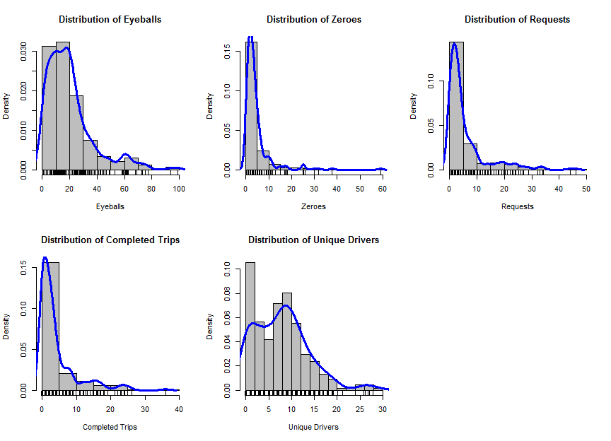

## Correlation of 5 numeric variables

By drawing a scatter plot matrix, we can identify if there is any correlations between all the numeric variables.

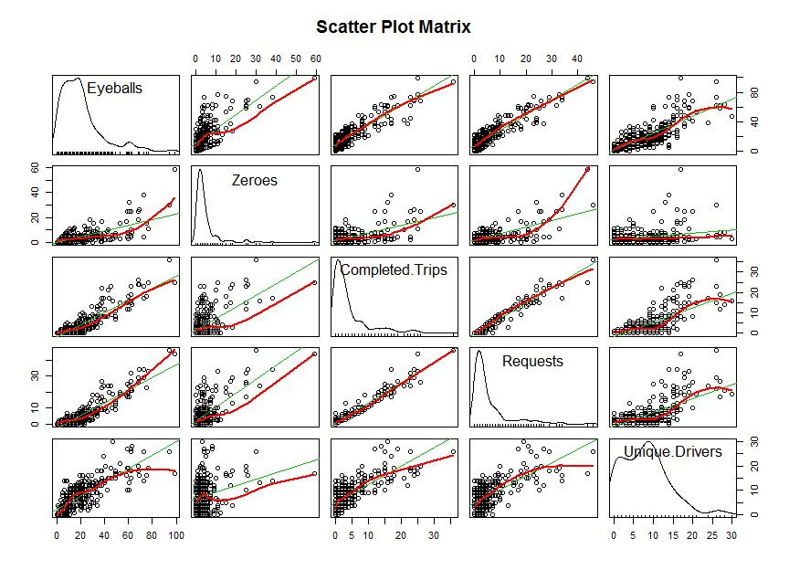

It looks like there is a positive correlation between demand(Eyeballs) and supply(Unique Drivers) based on the plot. So we will further calculate the correlation coefficient. A correlation coefficient of 0.79 suggests strong positive relationship between supply and demand.

```r
cor(uberNum$Eyeballs, uberNum$Unique.Drivers)
```

```
## [1] 0.7895826
```

## Exploration by Category

After examining numeric variables solely, we will analyze them by categorical groups, that, in this case, are Date and Time.

### Most Completed Trips by Date and Time

It is clearly that completed trips centralize in weekends(Saturday and Sunday) and in peak hours(5pm - 3am), according to the graph.

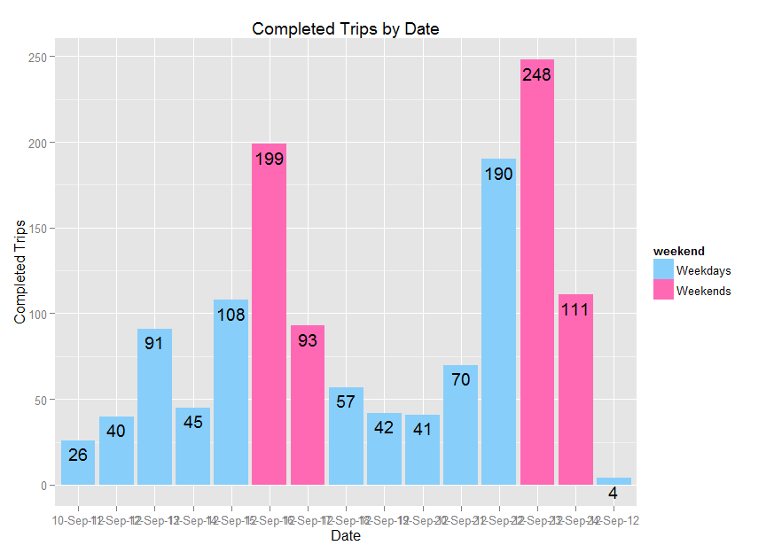

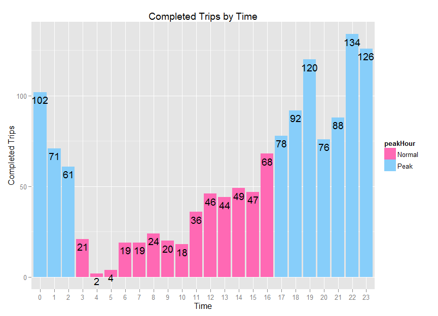

### The Gap between Demand and Supply

The core concept of the business is about the optimization between demand(Eyeballs) and supply(Unique Drivers). So we are going to explore the pattern of gap (`uber$Eyeballs-uber$Unique.Drivers`) by date and time. It is clearly that there are still lots of positive bars, especially in Friday night and Saturday.

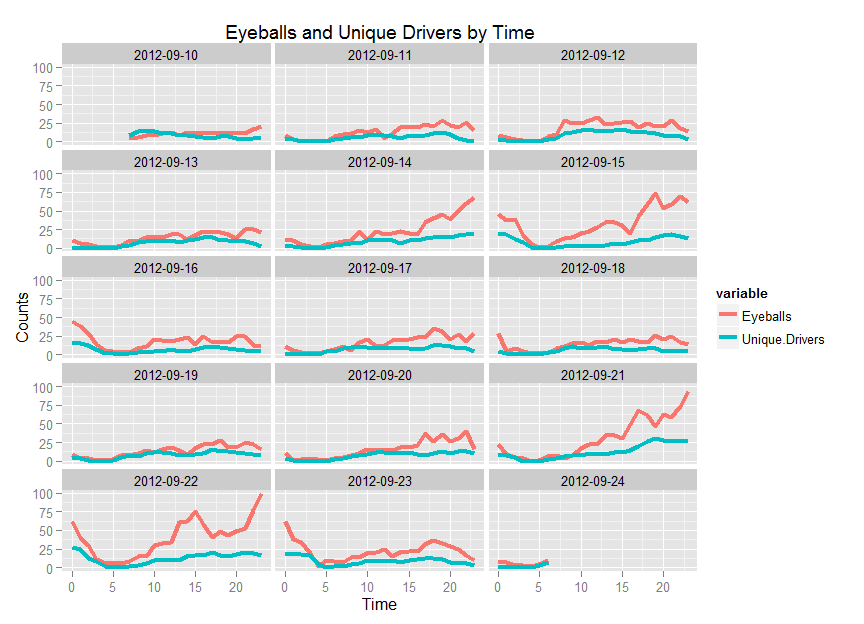

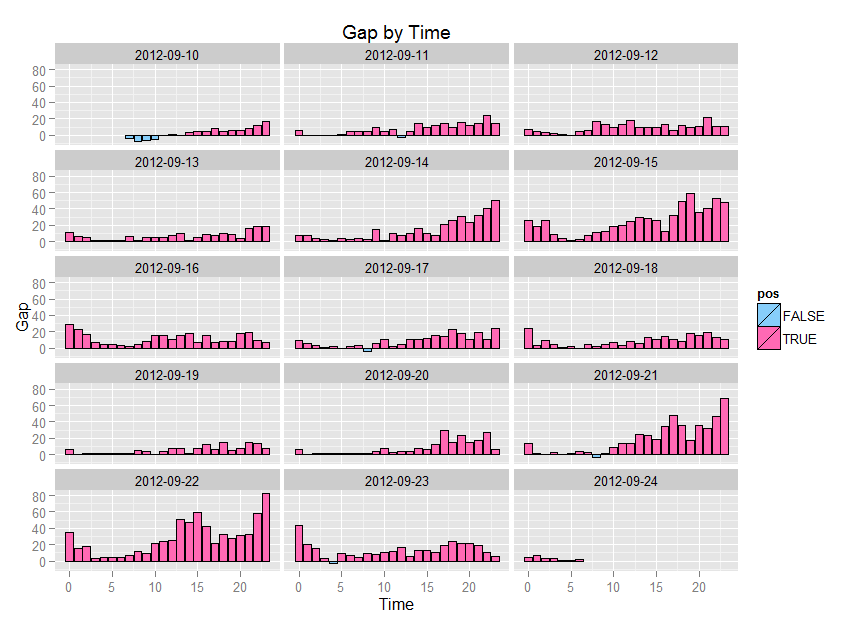

### Zeroes in Popular Hours

Zeroes might directly result in drop-outs(turning off the App.) Besides watching patterns of Eyeballs and Online Drivers, we also have to pay attention to zeroes, especially in Popular Hours. According to the exercise, Popular Hours are defined as 5pm in Friday to 3am in Sunday. And there are still plenty of Zeroes during Popular Hours according to the graph.

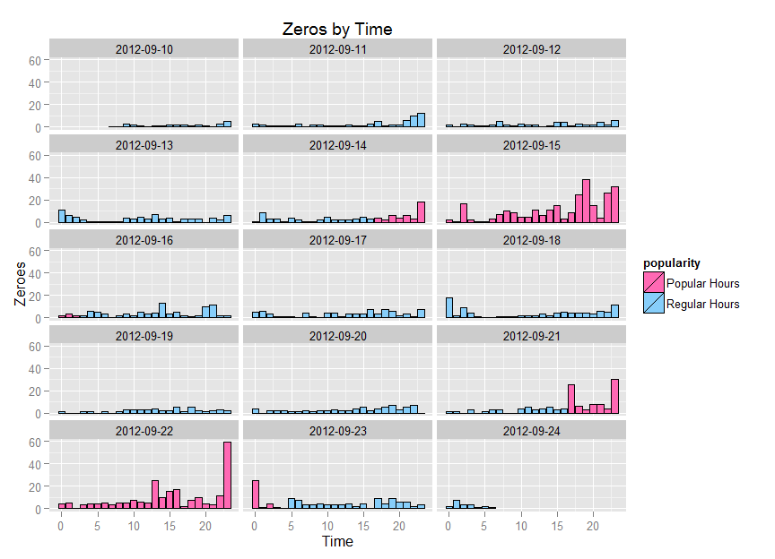

# Conclusion

- The most important target is to maximize Completed Trips.
  - Nice balance between Eyeballs and Unique Drivers results in more requests, thus results in more Completed Trips.
  - Zeros result in less requests, hence result in fewer Completed Trips.
- Most of the Completed Trips come from Popular Hours(from 5pm on Friday to 3am on Sunday). Yet, there are still plenty of business opportunities lost in these hours.
- Incentive plans or marketing campaigns shall focus on the how to reduce Zeros during Popular Hours.
  - Dynamic pricing on riders might decrease Eyeballs during Popular Hours.
  - Therefore, if I were about to make a suggestion, I will go for a dynamic pricing on drivers’ proportion of revenue share, rather than on riders.
- The definition of Popular Hours should be considered more thoroughly besides considering Date and Time only. Say, adding dimensions including national holidays, seasons, and climate etc. into the definition of Popular Hours. The more precise Uber can predict popularity, the more Completed Trips can be accomplished.

For a more detailed learning for Uber Analytics, you could visit [https://www.deskbright.com/uber/uber-analytics-test/)](https://www.deskbright.com/uber/uber-analytics-test/).